# Lab1: Demo RMarkdown & EDA

MAT43 Statistical Machine Learning

Silvia Montagna (edited by Claudio Peroni)

03/06/2018

# Exercise 8 from ISLR Chapter 2

The following illustrate commands for exploring this exercise using R and various packages for the `College` data. The `College` dataset contains a number of variables for 777 different universities and colleges in the US.

#### Note

On macOs, to run the next chunk the shortcut is different from what is displayed under the *run* menu:

```r
cmd+alt+n
```

### Libraries

Try to load the `ISLR` library

```r
library(ISLR)
```

If it is not available you will need to install the library from CRAN. Click on *Packages* then *Install*. Enter the package name then click on the Install button.

You can also install from the console/command line using `install.packages("ISLR")`.

Ready?

### Getting the College data

Next we will need to load the dataset. This is part of the library so we will not need to read it in using `read.csv` but rather we will use the `data` function to load it from the library.

```r
data(College)
```

This loads the dataframe `College`. Note you can always see the content of any `R` object by simply typing its name, e.g. by typing `College` in the `R` console.

[output not shown]

[output cut: 5391 more lines]

[output not shown]

For information about the variables, read the text or enter

```r
help(College)
```

The info will appear in the `help` tab.

To explore the data, you can use the command `View(College)`. This will open a new tab, where you may scroll left and right to look at the rows and columns.

```r
View(College)
```

In the `View` you should see that the first column is the College/University name. These can be extracted using `rownames(College)`. Let’s print out the first 5

```r
rownames(College)[1:5]
```

```
## [1] "Abilene Christian University" "Adelphi University"
## [3] "Adrian College"               "Agnes Scott College"
## [5] "Alaska Pacific University"
```

### Summary

We can pull up basic information about the variables using the `summary()` function

```r
summary(College)
```

```
##  Private        Apps           Accept          Enroll       Top10perc
##  No :212   Min.   :   81   Min.   :   72   Min.   :  35   Min.   : 1.00
##  Yes:565   1st Qu.:  776   1st Qu.:  604   1st Qu.: 242   1st Qu.:15.00
##            Median : 1558   Median : 1110   Median : 434   Median :23.00
##            Mean   : 3002   Mean   : 2019   Mean   : 780   Mean   :27.56
##            3rd Qu.: 3624   3rd Qu.: 2424   3rd Qu.: 902   3rd Qu.:35.00
##            Max.   :48094   Max.   :26330   Max.   :6392   Max.   :96.00
##    Top25perc      F.Undergrad     P.Undergrad         Outstate
##  Min.   :  9.0   Min.   :  139   Min.   :    1.0   Min.   : 2340
##  1st Qu.: 41.0   1st Qu.:  992   1st Qu.:   95.0   1st Qu.: 7320
##  Median : 54.0   Median : 1707   Median :  353.0   Median : 9990
##  Mean   : 55.8   Mean   : 3700   Mean   :  855.3   Mean   :10441
##  3rd Qu.: 69.0   3rd Qu.: 4005   3rd Qu.:  967.0   3rd Qu.:12925
##  Max.   :100.0   Max.   :31643   Max.   :21836.0   Max.   :21700
##    Room.Board       Books           Personal         PhD
##  Min.   :1780   Min.   :  96.0   Min.   : 250   Min.   :  8.00
##  1st Qu.:3597   1st Qu.: 470.0   1st Qu.: 850   1st Qu.: 62.00
##  Median :4200   Median : 500.0   Median :1200   Median : 75.00
##  Mean   :4358   Mean   : 549.4   Mean   :1341   Mean   : 72.66
##  3rd Qu.:5050   3rd Qu.: 600.0   3rd Qu.:1700   3rd Qu.: 85.00
##  Max.   :8124   Max.   :2340.0   Max.   :6800   Max.   :103.00
##     Terminal       S.F.Ratio      perc.alumni        Expend
##  Min.   : 24.0   Min.   : 2.50   Min.   : 0.00   Min.   : 3186
##  1st Qu.: 71.0   1st Qu.:11.50   1st Qu.:13.00   1st Qu.: 6751
##  Median : 82.0   Median :13.60   Median :21.00   Median : 8377
##  Mean   : 79.7   Mean   :14.09   Mean   :22.74   Mean   : 9660
##  3rd Qu.: 92.0   3rd Qu.:16.50   3rd Qu.:31.00   3rd Qu.:10830
##  Max.   :100.0   Max.   :39.80   Max.   :64.00   Max.   :56233
##    Grad.Rate
##  Min.   : 10.00
##  1st Qu.: 53.00
##  Median : 65.00
##  Mean   : 65.46
##  3rd Qu.: 78.00
##  Max.   :118.00
```

We can also display the type of variable of each column, applying the funciton `class()` with `sapply()`

```r
sapply(College, class)
```

```
##     Private        Apps      Accept      Enroll   Top10perc   Top25perc
##    "factor"   "numeric"   "numeric"   "numeric"   "numeric"   "numeric"
## F.Undergrad P.Undergrad    Outstate  Room.Board       Books    Personal
##   "numeric"   "numeric"   "numeric"   "numeric"   "numeric"   "numeric"
##         PhD    Terminal   S.F.Ratio perc.alumni      Expend   Grad.Rate
##   "numeric"   "numeric"   "numeric"   "numeric"   "numeric"   "numeric"
```

### Data dimension

How many observations and variables are in the dataframe?

```r
d = dim(College)
d
```

```
## [1] 777  18
```

Suppose we want to refer to those numbers in the text. We can extract them using n = 777 and d = 18. Look at the Rmd code to see how we extracted them. To extract themi in R:

```r
n = d[1]
n
```

```
## [1] 777
```

```r
r = d[2]
r
```

```
## [1] 18
```

### Scatter plot matrices

This `base` `R` version of scatter plot matrices is obtained using the `pairs` function to plot all variables versus each other. We can use subsetting of columns of the dataframe to look at the first 5 columns.

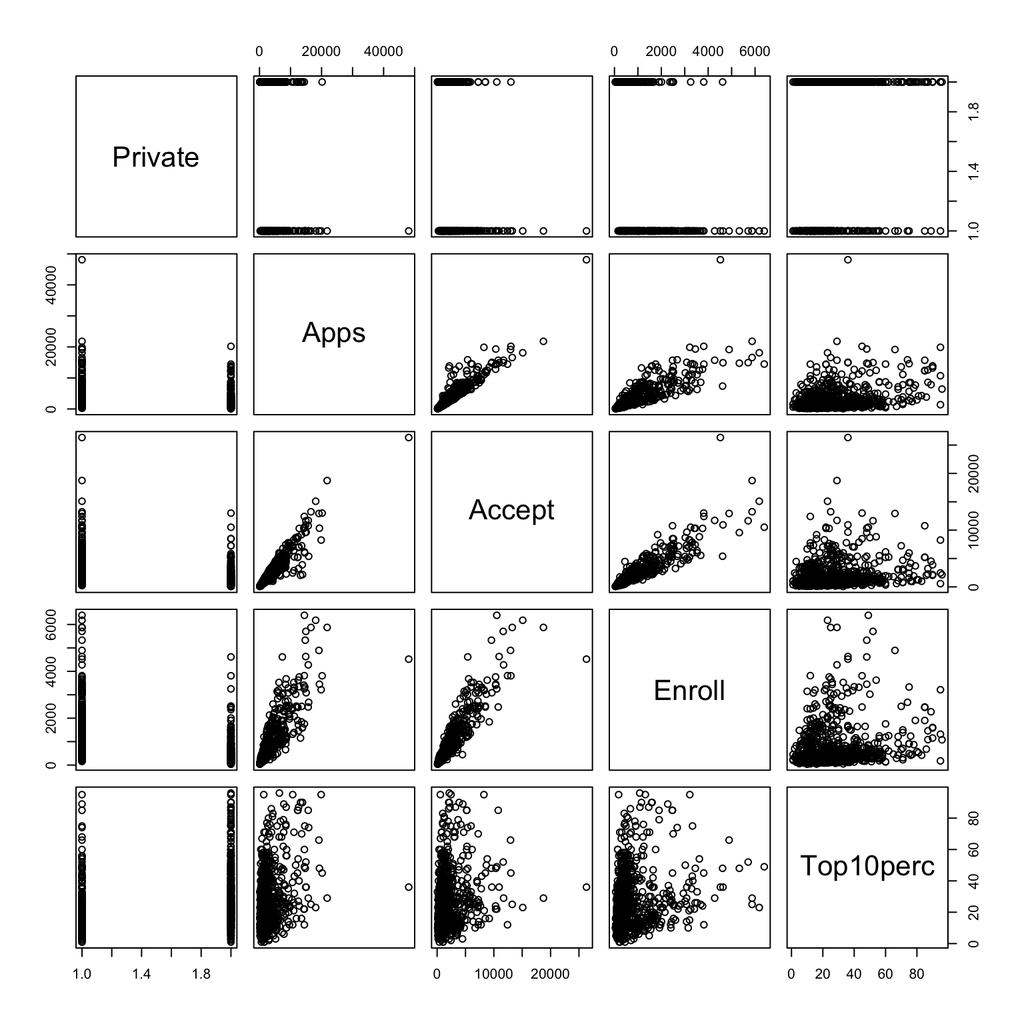

```r
pairs(College[, 1:5])
```

We can also look at this using the `ggpairs` function. Install the library `GGally` if it is not available (and any dependent libraries) and load it.

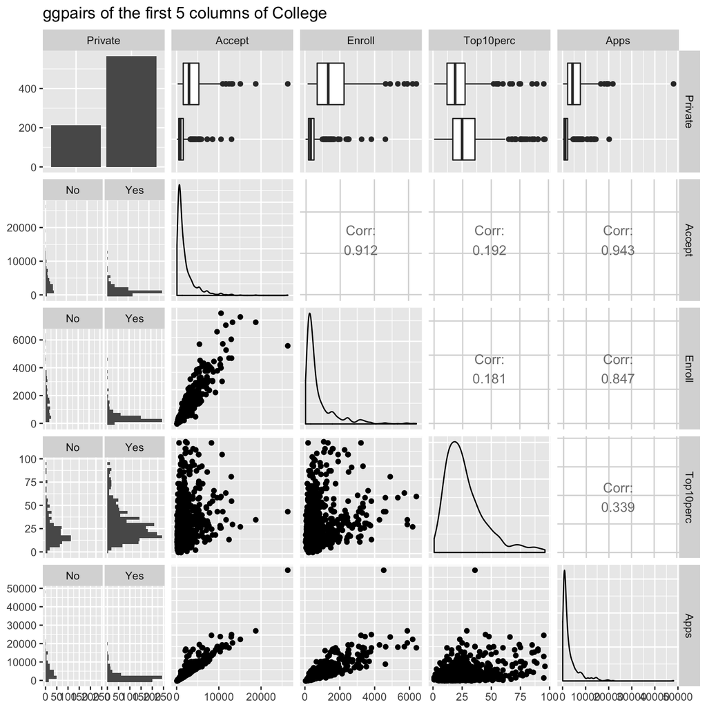

```r
library(GGally)
ggpairs(College, columns= c(1,3:5, 2), title = "ggpairs of the first 5 columns of College", showStrips = TRUE, axisLabels = TRUE)
```

*TODO*: Try to better display the scale in each plot

The last variable `Apps` is our response. This is the reason why we postponed it to the last column. It indicates the number of applications received.

The `ggpairs` function realizes that the variable `Private` is categorial and plots side by side histograms. The density plots are also useful for seeing the skewness in the marginal distributions.

What other features do these plots indicate?

### New variables

Let’s create a new variable `Elite` by binning the `Top10perc` variable. We are going to divide universities into two groups based on whether or not the proportion of students coming from the top 10% of their high school classes exceeds 50%. We will use the library `dplyr` to illustrate some of the possible transformations and the idea of pipes, which are quite powerful once you get the hang of them!

```r
library(dplyr)
College = College %>%
  mutate(Elite = factor(Top10perc > 50)) %>%
  mutate(Elite = recode(Elite, 'TRUE' = "Yes", 'FALSE' = "No"))
College
```

[output not shown]

[output cut: 2319 more lines]

*What is the above doing?* Document the code here.

Compare to the base `R` code:

```r
Elite = rep("No", nrow(College))
Elite[College$Top10perc > 50] = "Yes"
Elite = as.factor(Elite)
college = data.frame(College, Elite)
```

*How many Elite Universities are there?*

```r
summary(College$Elite)
```

```
##  No Yes
## 699  78
```

### Side-by-side boxplots

Let’s plot the variable `Outstate` versus `Elite` using side-by-side boxplots. Using `base R` we would enter:

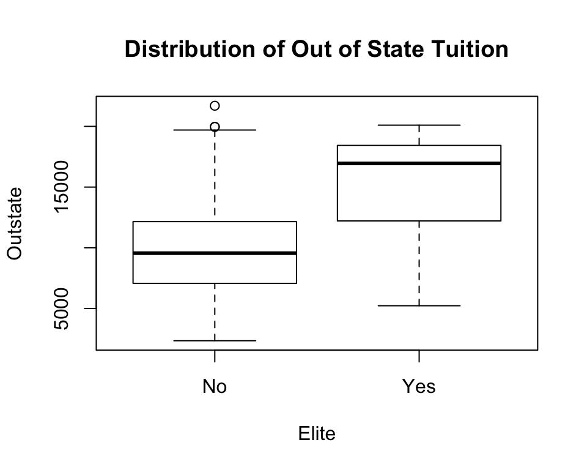

```r
boxplot(Outstate ~ Elite, data = College, ylab = "Outstate", xlab = "Elite")
title("Distribution of Out of State Tuition")
```

Now for the `ggplot` version:

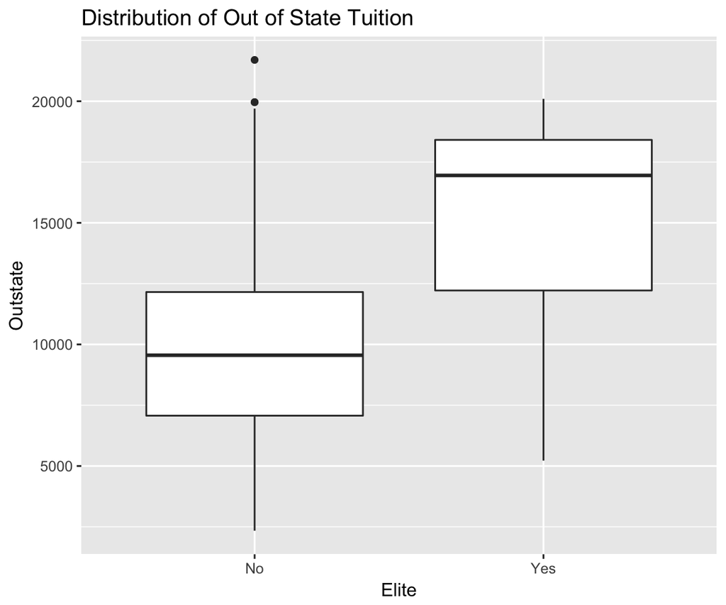

```r
library(ggplot2)
my.bp <- ggplot(data = College, aes(y = Outstate, x = Elite)) # Creates boxplots
my.bp <- my.bp + geom_boxplot() # Adds color
my.bp <- my.bp + ggtitle("Distribution of Out of State Tuition") # Adds a title
my.bp <- my.bp +  ylab("Outstate") + xlab("Elite") # Adds lables for axes
my.bp # displays the boxplots
```

### Conditional Plots

Let’s look at the distribution of out of state tuition (`Outstate`) versus Elite status for Private versus Public universities using *conditional plots*

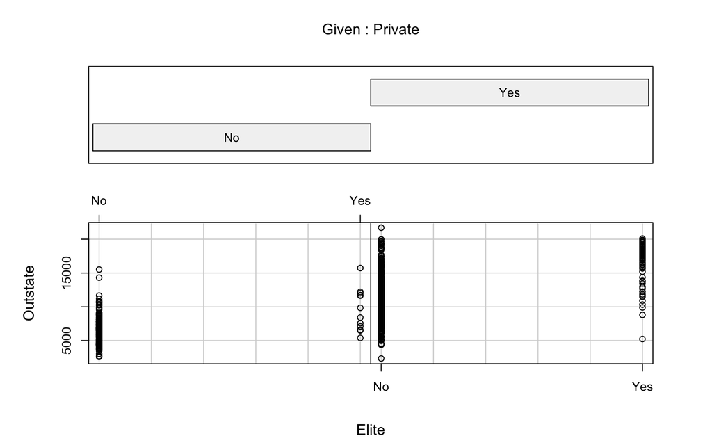

```r
coplot(Outstate ~ Elite | Private, data = College)
```

## ggplot conditional plot

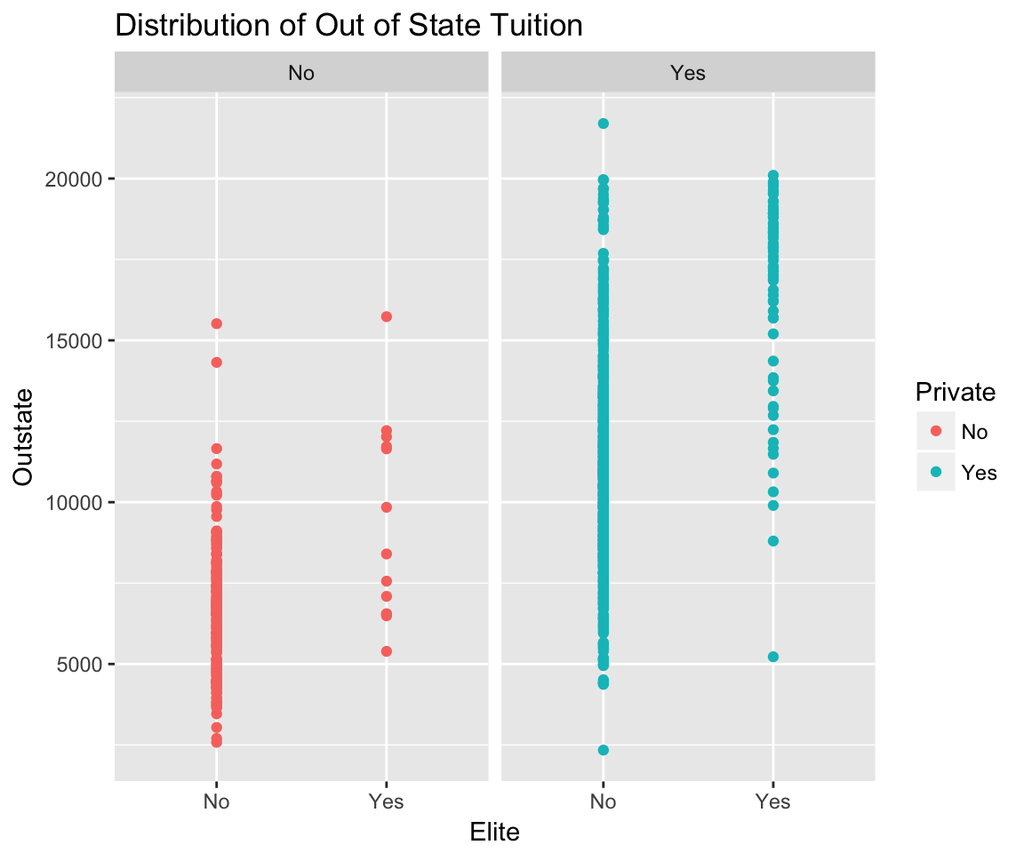

```r
library(ggplot2)
ggplot(College, aes(x = Elite, y = Outstate,
                    group = Private,
                    colour = Private)) +
   geom_point() + facet_grid(.~Private) + ggtitle("Distribution of Out of State Tuition")
```

## Next Steps

Update this document and explore the other variables thinking about the objective of predicting `Apps`. Document what you discover thinking about models to predict `Apps`.

# On your own: the `Auto` dataset

This dataset was taken from the StatLib library which is maintained at Carnegie Mellon University. The dataset was used in the 1983 American Statistical Association Exposition. The dataset is available with the ISLR library.

Load the data and answer the following questions adding your code in the code chunks.

1. Create a summary of the data. How many variables have missing data?

```r
library(ISLR)
data(Auto)
summary(Auto)
```

```
##       mpg          cylinders      displacement     horsepower
##  Min.   : 9.00   Min.   :3.000   Min.   : 68.0   Min.   : 46.0
##  1st Qu.:17.00   1st Qu.:4.000   1st Qu.:105.0   1st Qu.: 75.0
##  Median :22.75   Median :4.000   Median :151.0   Median : 93.5
##  Mean   :23.45   Mean   :5.472   Mean   :194.4   Mean   :104.5
##  3rd Qu.:29.00   3rd Qu.:8.000   3rd Qu.:275.8   3rd Qu.:126.0
##  Max.   :46.60   Max.   :8.000   Max.   :455.0   Max.   :230.0
##
##      weight      acceleration        year           origin
##  Min.   :1613   Min.   : 8.00   Min.   :70.00   Min.   :1.000
##  1st Qu.:2225   1st Qu.:13.78   1st Qu.:73.00   1st Qu.:1.000
##  Median :2804   Median :15.50   Median :76.00   Median :1.000
##  Mean   :2978   Mean   :15.54   Mean   :75.98   Mean   :1.577
##  3rd Qu.:3615   3rd Qu.:17.02   3rd Qu.:79.00   3rd Qu.:2.000
##  Max.   :5140   Max.   :24.80   Max.   :82.00   Max.   :3.000
##
##                  name
##  amc matador       :  5
##  ford pinto        :  5
##  toyota corolla    :  5
##  amc gremlin       :  4
##  amc hornet        :  4
##  chevrolet chevette:  4
##  (Other)           :365
```

```r
summary(is.na(Auto))
```

```
##     mpg          cylinders       displacement    horsepower
##  Mode :logical   Mode :logical   Mode :logical   Mode :logical
##  FALSE:392       FALSE:392       FALSE:392       FALSE:392
##    weight        acceleration       year           origin
##  Mode :logical   Mode :logical   Mode :logical   Mode :logical
##  FALSE:392       FALSE:392       FALSE:392       FALSE:392
##     name
##  Mode :logical
##  FALSE:392
```

2. Which of the predictors are quantitative, and which are qualitative?

```r
help(Auto)
typeAuto = sapply(Auto, class) #Automatic type detection
typeAuto
```

```
##          mpg    cylinders displacement   horsepower       weight
##    "numeric"    "numeric"    "numeric"    "numeric"    "numeric"
## acceleration         year       origin         name
##    "numeric"    "numeric"    "numeric"     "factor"
```

3. What is the range of each quantitative predictor? You can answer this using the `range()` function. Create a table with variable name, min, max with one row per variable. `kable` from the package `knitr` can display tables nicely.

```r
library(knitr)

table = t(sapply(Auto[typeAuto=="numeric"], range)) # Creates min-max table only for numerical values
kable(table, col.names = c("min", "max"))
```

|  | min | max |
| --- | --- | --- |
| mpg | 9 | 46.6 |
| cylinders | 3 | 8.0 |
| displacement | 68 | 455.0 |
| horsepower | 46 | 230.0 |
| weight | 1613 | 5140.0 |
| acceleration | 8 | 24.8 |
| year | 70 | 82.0 |
| origin | 1 | 3.0 |

4. What is the mean and standard deviation of each quantitative predictor? *Format nicely in a table as above*
5. Now remove the 10th through 85th observations (try this with `filter` from the `dplyr` package). What is the range, mean, and standard deviation of each predictor in the subset of the data that remains? *Again, present the output as a nicely formatted table*
6. Investigate the predictors graphically, using scatterplot matrices (`ggpairs`) and other tools of your choice. Create some plots highlighting the relationships among the predictors. Comment on your findings. *Try adding a caption to your figure*
7. Suppose that we wish to predict gas mileage (`mpg`) on the basis of the other variables using regression. Do your plots suggest that any of the other variables might be useful in predicting mpg using linear regression? Justify your answer.